# Overall CPU Analysis

### Abstract

CPU has become a big part of our lives. It is in our phones, desktop, laptop, glasses and even toasters.this report will illustrate how CPUs are improving and where is the future headed by comparing data gathered from two well known websites with over 3000 CPUs analyzed.

### Introduction

Everyone knows what is a CPU (central processing unit), but what makes CPUs so different from each other. On one hand one might find an expensive CPU that offers low performance, while the other might find a CPU with higher performance but with half the price of the expansive one. No matter how different is the CPU architecture from one another they will always have common variables that are sheared with the consumer. We will be using some of these variables to analysis the datasets acquired. The first keyword we will be using is TDP which stands for Thermal design power which means how much power is consumed when the CPU is on full power and it is measured by watts. The keyword CPU Transistor Size, refers to the size of transistor that are fitted on the CPU itself and it is measured by nm which stands for nanometer. Lastly, the keyword CPU multiplier refers to the speed ratio between the front side bus (FSB) and the CPU.

This report will seek to answer the following questions:

1. Which CPU has the most efficient power consumed per watts ?
2. Does price effect performance?
3. Does the CPU clock speed effect the power usage?
4. What does multiplier effect in a CPU ?
5. Is it true that the CPU Transistor Size does not reflect performance ?
6. Does lower CPU Transistor Size means more power efficiency ?
7. What can we predict for CPU future ?

Links to the dataset can be found below:

```python
from IPython.core.display import HTML
HTML("<iframe src=http://www.cpubenchmark.net/cpu_list.php width=400 height=350></iframe>\\
      <iframe src=http://www.techpowerup.com/cpudb/index.php width=500 height=350></iframe>")
```

[interactive chart not shown]

\

[interactive chart not shown]

### Analysis

##### Datasets

```python
import pandas as pd
import numpy as np
import matplotlib.pyplot as plt
import statsmodels.formula.api as smf
import math
import re

# Set some Pandas options as you like
pd.set_option('html', True)
pd.set_option('max_columns', 20)
pd.set_option('max_rows', 20)

#this line enables the plots to be embedded into the notebook
%matplotlib inline
```

#### First we read the data to see how it looks like.

The two dataset are provided from cpubenchmark.net and techpowerup.com. The first dataset is a huge data about all CPUs specification from 2000 to early 2014. The second dataset contains the price and the CPU benchmarks (Passmark) among other data.

```python
cpu_info = pd.read_csv("dataset/cpu_database.csv")
cpu_bench = pd.read_csv("dataset/cpu_list.csv")
```

```python
cpu_info.head(5)
```

|  | Name | Codename | Cores | Socket | Process | Clock | Multi | Voltage | Cache L1/L2/L3 | TDP | Released |
| --- | --- | --- | --- | --- | --- | --- | --- | --- | --- | --- | --- |
| 0 | A10-7850K | Kaveri | 4-Core | AMD Socket FM2 | 28 nm | 3700 MHz | 37.0x | 1.475 V | 128K / 1024K / 0K | 95W | Jan 2014 |
| 1 | A10-7700K | Kaveri | 4-Core | AMD Socket FM2 | 28 nm | 3500 MHz | 35.0x | 1.475 V | 128K / 1024K / 0K | 95W | Jan 2014 |
| 2 | A10-6790K | Richland | 4-Core | AMD Socket FM2 | 32 nm | 4000 MHz | 40.0x | 1.475 V | 128K / 1024K / 0K | 100W | Oct 2013 |
| 3 | A10-6700T | Richland | 4-Core | AMD Socket FM2 | 32 nm | 2500 MHz | 25.0x | 1.475 V | 128K / 1024K / 0K | 45W | Sep 2013 |
| 4 | FX-9370 | Vishera | 8-Core | AMD Socket AM3+ | 32 nm | 4400 MHz | 22.0x | 1.912 V | 384K / 8192K / 8192K | 220W | Jul 2013 |

5 rows × 11 columns

```python
cpu_bench.head(5)
```

|  | CPU Name | Passmark CPU Mark (higher is better) | Rank (lower is better) | CPU Value (higher is better) | Price (USD) |
| --- | --- | --- | --- | --- | --- |
| 0 | 686 Gen | 288 | 1717 | NaN | NaN |
| 1 | A8-7600B Radeon R7 10 Compute Cores 4C+6G | 4468 | NaN | NaN | NaN |
| 2 | AMD A10 PRO-7350B APU | 3106 | NaN | NaN | NaN |
| 3 | AMD A10-4600M APU | 3131 | 515 | NaN | NaN |
| 4 | AMD A10-4655M APU | 2579 | 626 | NaN | NaN |

5 rows × 5 columns

To make accessing cpu_bench dataset easier the columns names will be changed.

```python
cpu_bench.columns = ['Name', 'Passmark', 'Rank', 'Value', 'Price']
cpu_bench.dropna().head(5)
```

|  | Name | Passmark | Rank | Value | Price |
| --- | --- | --- | --- | --- | --- |
| 6 | AMD A10-5700 APU | 4222 | 345 | 31.70 | $133.18 |
| 11 | AMD A10-5800K APU | 4657 | 298 | 38.82 | $119.99 |
| 12 | AMD A10-6700 APU | 4708 | 292 | 31.60 | $148.99 |
| 13 | AMD A10-6790K APU | 4745 | 289 | 33.90 | $139.99 |
| 15 | AMD A10-6800K APU | 4786 | 281 | 31.91 | $149.99 |

5 rows × 5 columns

Define functions to help reduce code debuliction

```python
#filters
fter = '[^0-9\.]+'
fterABC = '[^A-Za-z]+'
filtter = '[^A-Za-z0-9]+'

#jan 2014 --> 1
def MonthToInt(month):
    date = re.sub(fterABC, ' ', month).lower()
    if 'jan' in date:
        return 1
    elif 'feb' in date:
        return 2
    elif 'mar' in date:
        return 3
    elif 'apr' in date:
        return 4
    elif 'may' in date:
        return 5
    elif 'jun' in date:
        return 6
    elif 'jul' in date:
        return 7
    elif 'aug' in date:
        return 8
    elif 'sep' in date:
        return 9
    elif 'oct' in date:
        return 10
    elif 'nov' in date:
        return 11
    elif 'dec' in date:
        return 12
    else:
        return 0

# Remove a pattren from a list
def RemoveUnwanted(datasample, fpattren):
    count = 0
    for oneRaw in datasample:
        datasample[count]= float(re.sub(fpattren, '', oneRaw))
        count+=1

# Draw Poly line
def curvLine(x, y, dta, poly_num, color='r-'):
    x1 = pd.DataFrame({'x': np.linspace(x.min(), x.max(), len(dta))})
    # 2-nd order polynomial
    if poly_num ==1:
        poly_ = smf.ols(formula='y ~ 1 + x', data=dta).fit()
    elif poly_num == 2:
        poly_ = smf.ols(formula='y ~ 1 + x + I(x ** 2.0)', data=dta).fit()
    elif poly_num == 3:
        poly_ = smf.ols(formula='y ~ 1 + x + I(x ** 2.0) + I(x ** 3.0)', data=dta).fit()
    plt.plot(x1.x, poly_.predict(x1), color, label='Poly n=%d $R^2$=%.2f' % (poly_num,poly_.rsquared),alpha=0.9)
    plt.legend()
# ceil a number to a specific decimal
def roundup(x, rou=20):
    return int(math.ceil(x / rou)) * rou
```

We manipulate data so we will end up with straight data types (int, float ,etc). To avoid errors as well

```python
cpu_bench.fillna("0", inplace=True)
cpu_info.fillna("0", inplace=True)
cpu_info.replace("unknown", "0", inplace=True)
RemoveUnwanted(cpu_info.Cores, fter)   # 4-cores --> 4
RemoveUnwanted(cpu_info.Voltage, fter) # 1.4v    --> 1.4
RemoveUnwanted(cpu_info.TDP, fter)     # 80W     --> 80
RemoveUnwanted(cpu_info.Process, fter) # 22nm    --> 22
RemoveUnwanted(cpu_info.Clock, fter)   # 4000hz  --> 4000
RemoveUnwanted(cpu_info.Multi, fter)   # 23x     --> 23
RemoveUnwanted(cpu_bench.Price, fter)  # $100    --> 100
count = 0
# jan 2014 --> 2014.1
for key2 in cpu_info.Released:
    cpu_info.Released[count] = float(re.sub(fter, '', key2)) + float(MonthToInt(key2))/10
    count+=1
```

In the dataset we have some data that belongs to multiple cpu configuration, we are removing them so it will not affect the result of our anylsis.

```python
cpu_bench = cpu_bench[~(cpu_bench.Name.str.startswith("["))]
```

We have an issue with the two tables, the keys are not in the same formate. We can try to match a single key from the cpu_database (i7-3770K) with the cpu_bench.

```python
count = 0
for key1 in cpu_bench.Name:
    info_count = 0
    for key2 in cpu_info.Name:
        if key2.lower() in key1.lower():
            count=count+1
            cpu_info.Name[info_count] = key1
        info_count+=1
print "cpu_bench has %d keys, while we matched only %d keys" % (len(cpu_bench),count)
```

```
cpu_bench has 1949 keys, while we matched only 1133 keys
```

# Now we can merge the two Datasets.

```python
cpu_merged = pd.merge(cpu_info,cpu_bench, on='Name')
cpu_merged.head(5)
```

|  | Name | Codename | Cores | Socket | Process | Clock | Multi | Voltage | Cache L1/L2/L3 | TDP | Released | Passmark | Rank | Value | Price |
| --- | --- | --- | --- | --- | --- | --- | --- | --- | --- | --- | --- | --- | --- | --- | --- |
| 0 | AMD A10-7850K APU | Kaveri | 4 | AMD Socket FM2 | 28 | 3700 | 37 | 1.475 | 128K / 1024K / 0K | 95 | 2014.1 | 5680 | 225 | 33.42 | 169.99 |
| 1 | AMD A10-7700K APU | Kaveri | 4 | AMD Socket FM2 | 28 | 3500 | 35 | 1.475 | 128K / 1024K / 0K | 95 | 2014.1 | 5404 | 245 | 33.78 | 159.99 |
| 2 | AMD A10-6790K APU | Richland | 4 | AMD Socket FM2 | 32 | 4000 | 40 | 1.475 | 128K / 1024K / 0K | 100 | 2014 | 4745 | 289 | 33.9 | 139.99 |
| 3 | AMD FX-9370 Eight-Core | Vishera | 8 | AMD Socket AM3+ | 32 | 4400 | 22 | 1.912 | 384K / 8192K / 8192K | 220 | 2013.7 | 9680 | 55 | 42.09 | 229.99 |
| 4 | AMD FX-9590 Eight-Core | Vishera | 8 | AMD Socket AM3+ | 32 | 4700 | 23.5 | 1.912 | 384K / 8192K / 8192K | 220 | 2013.7 | 10294 | 36 | 34.32 | 299.99 |

5 rows × 15 columns

## Price vs Performance

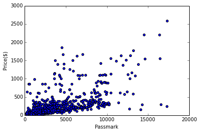

```python
test_price =  cpu_bench[cpu_bench.Price>0]
plt.scatter( test_price.Passmark,test_price.Price)
plt.xlim(0,20000)
plt.ylim(0,3000)
plt.xlabel("Passmark")
plt.ylabel("Price($)")
plt.show()
```

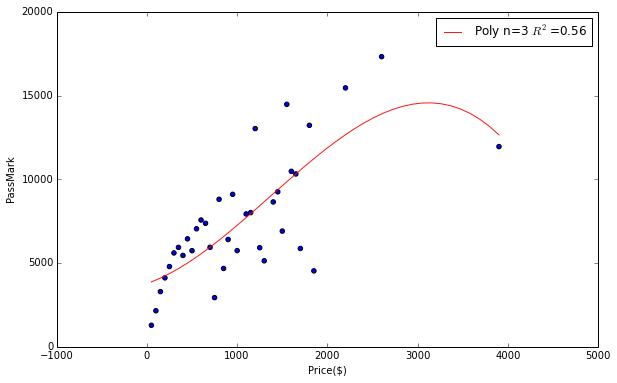

```python
test = pd.DataFrame(index=range(int(cpu_bench.Price.max()+10)), columns=['Pass','Cpus'])
test.fillna(0, inplace=True)

count=0
for x in cpu_bench.Price:
    test.Pass[roundup(x, 50)] += cpu_bench.Passmark[count]
    if x >0 :
        test.Cpus[roundup(x, 50)]+=1
    count+=1
test = test[test.Cpus >0]
test
test['average'] = (test.Pass/test.Cpus)
test['Price'] = test.index
plt.figure(figsize=(6 * 1.618, 6))
plt.scatter(test.Price, test.average)
plt.xlabel("Price($)")
plt.ylabel("PassMark")
curvLine(test.Price, test.average, test,3)
```

## Higher Clock speed affect the power usage

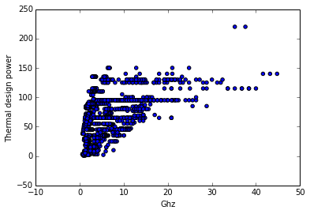

```python
plt.scatter((cpu_info.Clock*cpu_info.Cores)/1000, cpu_info.TDP)
plt.xlabel("Ghz")
plt.ylabel("Thermal design power")
plt.show()
```

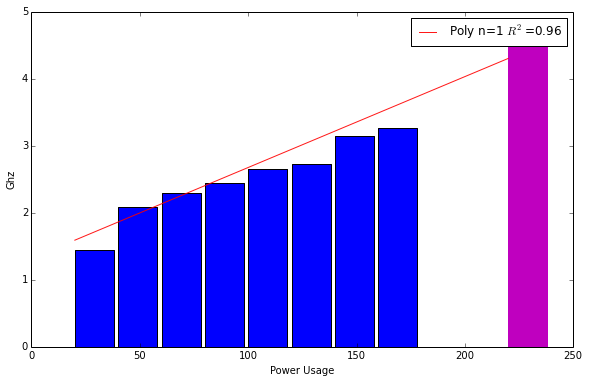

```python
test = pd.DataFrame(index=range(len(cpu_info.TDP)), columns=['TDP','Cpus'])
test.fillna(0, inplace=True)

count=0
for x in cpu_info.TDP:
    test.TDP[roundup(x)] += (cpu_info.Clock[count])#*cpu_info.Cores[count]
    test.Cpus[roundup(x)]+=1
    count+=1
test = test[test.TDP >0]
test['average'] = (test.TDP/test.Cpus)/1000
test['TDP'] = test.index
plt.figure(figsize=(6 * 1.618, 6))
# test[['average']].plot(kind='bar')
bars = plt.bar(test.index, test.average, width=18)
bars[test.index.size-1].set_color('m')
plt.xlabel("Power Usage")
plt.ylabel("Ghz")
curvLine(test.TDP, test.average, test,1)
plt.show()
```

### Performance / Power usage value vs trasistor size

To know which CPU is the most power efficient we need to create a new column(PowerValue) which contains the Passmark divided by the maximum power usage.

```python
cpu_merged['PowerValue'] = cpu_merged.Passmark/cpu_merged.TDP
```

The first table below shows the most power efficient CPUs, the second table shows the least efficient CPUs. We can observe that the most efficient share the same (Process) CPU Transistor Size (22) where the least have different sizes of 130 and over.

```python
cpu_merged.sort(columns=['PowerValue'], ascending=False).head(5)
```

|  | Name | Codename | Cores | Socket | Process | Clock | Multi | Voltage | Cache L1/L2/L3 | TDP | Released | Passmark | Rank | Value | Price | PowerValue |
| --- | --- | --- | --- | --- | --- | --- | --- | --- | --- | --- | --- | --- | --- | --- | --- | --- |
| 634 | Intel Atom Z3740 @ 1.33GHz | Bay Trail-T | 4 | Intel BGA1380 | 22 | 1333 | 10 | 0 | 64K / 512K / 0K | 2 | 2013.9 | 1073 | 1180 | 0 | 0 | 536.5 |
| 890 | Intel Xeon E3-1230L v3 @ 1.80GHz | Haswell | 4 | Intel Socket 1150 | 22 | 1800 | 18 | 0 | 64K / 256K / 8192K | 25 | 2013.6 | 7344 | 0 | 0 | 0 | 293.76 |
| 639 | Intel Core i7-4600U @ 2.10GHz | Haswell | 2 | Intel BGA1168 | 22 | 2100 | 21 | 0 | 64K / 256K / 4096K | 15 | 2013.9 | 4343 | 326 | 0 | 0 | 289.5333 |
| 650 | Intel Core i7-4650U @ 1.70GHz | Haswell | 2 | Intel BGA1168 | 22 | 1700 | 17 | 0 | 64K / 256K / 4096K | 15 | 2013.6 | 4173 | 351 | 0 | 0 | 278.2 |
| 678 | Intel Core i7-3689Y @ 1.50GHz | Ivy Bridge | 2 | Intel BGA1023 | 22 | 1500 | 20 | 0 | 64K / 256K / 4096K | 13 | 2013.1 | 3479 | 452 | 0 | 0 | 267.6154 |

5 rows × 16 columns

```python
cpu_merged.sort(columns=['PowerValue'], ascending=True).head(5)
```

|  | Name | Codename | Cores | Socket | Process | Clock | Multi | Voltage | Cache L1/L2/L3 | TDP | Released | Passmark | Rank | Value | Price | PowerValue |
| --- | --- | --- | --- | --- | --- | --- | --- | --- | --- | --- | --- | --- | --- | --- | --- | --- |
| 610 | Intel Pentium 4 2.00GHz | Northwood | 1 | Intel Socket 478 | 130 | 2000 | 15 | 1.5 | 8K / 512K / 0K | 110 | 2001.1 | 191 | 1825 | 0 | 0 | 1.736364 |
| 620 | Intel Pentium 4 1.70GHz | Willamette | 1 | Intel Socket 478 | 180 | 1700 | 17 | 1.75 | 8K / 256K / 0K | 64 | 2001.8 | 131 | 1853 | 0 | 0 | 2.046875 |
| 621 | Intel Pentium 4 1.70GHz | Willamette | 1 | Intel Socket 423 | 180 | 1700 | 17 | 1.75 | 8K / 256K / 0K | 64 | 2001.4 | 131 | 1853 | 0 | 0 | 2.046875 |
| 605 | Intel Pentium 4 2.26GHz | Northwood | 1 | Intel Socket 478 | 130 | 2261 | 17 | 1.5 | 8K / 512K / 0K | 110 | 2002.1 | 226 | 1797 | 0 | 0 | 2.054545 |
| 607 | Intel Pentium 4 2.00GHz | Northwood | 1 | Intel Socket 478 | 130 | 2000 | 20 | 1.5 | 8K / 512K / 0K | 92 | 2002.1 | 191 | 1825 | 0 | 0 | 2.076087 |

5 rows × 16 columns

The graphs below shows that the transistor size matter in relation to the performance per watt. The samller the transistor size that the CPU are using the more efficient it will be.

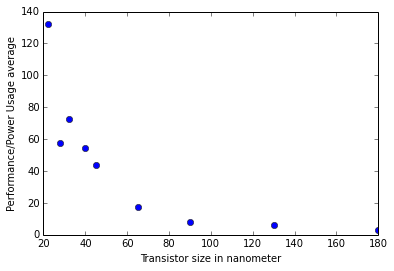

```python
dataPower = pd.DataFrame(index=range(0,200),columns=['cpus','total'])
dataPower.fillna(0, inplace=True)

count = 0
for key in cpu_merged.Process:
    dataPower.total[key]+=cpu_merged.PowerValue[count]
    dataPower.cpus[key]+=1
    count+=1

x = dataPower.index
y = dataPower.total/dataPower.cpus
plt.plot(x, y, marker='o')
plt.xlabel("Transistor size in nanometer")
plt.ylabel("Performance/Power Usage average")
plt.show()
```

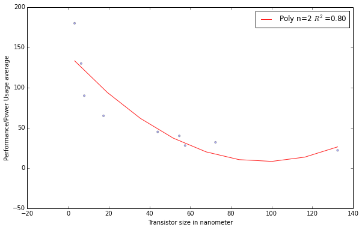

```python
cpu_merged['PowerValue'] = cpu_merged.Passmark/cpu_merged.TDP

dataPower = pd.DataFrame(index=range(0,200),columns=['cpus','total'])
dataPower.fillna(0, inplace=True)

count = 0
for key in cpu_merged.Process:
    dataPower.total[key]+=cpu_merged.PowerValue[count]
    dataPower.cpus[key]+=1
    count+=1
dataPower = dataPower[dataPower.total > 0]

tempData = pd.DataFrame(index =range(9))
tempData['data1'] = dataPower.index
tempData['nm'] = (dataPower.total/dataPower.cpus).values
plt.figure(figsize=(6 * 1.618, 6))
plt.scatter(tempData.nm, tempData.data1, s=10, alpha=0.3)

curvLine(tempData.nm, tempData.data1, tempData, 2)
plt.xlabel("Transistor size in nanometer")
plt.ylabel("Performance/Power Usage average")
plt.show()
```

[interactive chart not shown]

Game-debate show that the recommended cpu to run Battlefield 4 is Phenom II X6. Can we find a cheaper alternative ? Can we find the least power usage as well?

```python
# looks for the cheapest alternative
def LookForPrice(Name):
    return cpu_merged[(cpu_merged.Passmark >(cpu_merged[(cpu_merged.Name.str.contains(Name))].Passmark.min()))
           &(cpu_merged.Price != 0)&
           (cpu_merged.Price <200)].sort(columns='Price', ascending=True).head()
#looks for the least power usage alternative
def LookForPower(Name):
    return cpu_merged[(cpu_merged.Passmark >(cpu_merged[(cpu_merged.Name.str.contains(Name))].Passmark.min()))
           &(cpu_merged.Price != 0)&
           (cpu_merged.Price <200)].sort(columns='TDP', ascending=True).head()
```

```python
LookForPower('Phenom II X6')
```

|  | Name | Codename | Cores | Socket | Process | Clock | Multi | Voltage | Cache L1/L2/L3 | TDP | Released | Passmark | Rank | Value | Price | PowerValue |
| --- | --- | --- | --- | --- | --- | --- | --- | --- | --- | --- | --- | --- | --- | --- | --- | --- |
| 432 | Intel Core i3-4360 @ 3.70GHz | Haswell | 2 | Intel Socket 1150 | 22 | 3700 | 37 | 0 | 64K / 256K / 4096K | 54 | 2014.5 | 5643 | 228 | 35.28 | 159.99 | 104.5 |
| 443 | Intel Core i3-4340 @ 3.60GHz | Haswell | 2 | Intel Socket 1150 | 22 | 3600 | 36 | 0 | 64K / 256K / 4096K | 54 | 2013.9 | 5311 | 246 | 32.19 | 164.99 | 98.35185 |
| 444 | Intel Core i3-4330 @ 3.50GHz | Haswell | 2 | Intel Socket 1150 | 22 | 3500 | 35 | 0 | 64K / 256K / 4096K | 54 | 2013.9 | 5100 | 256 | 37.52 | 135.95 | 94.44444 |
| 447 | Intel Core i3-4130 @ 3.40GHz | Haswell | 2 | Intel Socket 1150 | 22 | 3400 | 34 | 0 | 64K / 256K / 3072K | 54 | 2013.9 | 4822 | 274 | 40.2 | 119.97 | 89.2963 |
| 436 | Intel Core i5-4590S @ 3.00GHz | Haswell | 4 | Intel Socket 1150 | 22 | 2900 | 29 | 0 | 64K / 256K / 6144K | 65 | 2014.5 | 7132 | 147 | 37.54 | 189.99 | 109.7231 |

5 rows × 16 columns

```python
LookForPrice('Phenom II X6')
```

|  | Name | Codename | Cores | Socket | Process | Clock | Multi | Voltage | Cache L1/L2/L3 | TDP | Released | Passmark | Rank | Value | Price | PowerValue |
| --- | --- | --- | --- | --- | --- | --- | --- | --- | --- | --- | --- | --- | --- | --- | --- | --- |
| 988 | Intel Xeon X5550 @ 2.67GHz | Gainestown | 4 | Intel Socket 1366 | 45 | 2666 | 20 | 1.35 | 64K / 256K / 8192K | 95 | 2009.3 | 5437 | 241 | 69.05 | 78.75 | 57.23158 |
| 987 | Intel Xeon E5540 @ 2.53GHz | Gainestown | 4 | Intel Socket 1366 | 45 | 2533 | 19 | 1.35 | 64K / 256K / 8192K | 80 | 2009.3 | 4802 | 276 | 53.37 | 90 | 60.025 |
| 21 | AMD FX-6300 Six-Core | Vishera | 6 | AMD Socket AM3+ | 32 | 3500 | 17.5 | 1.4 | 288K / 6144K / 8192K | 95 | 2013 | 6358 | 186 | 60.57 | 104.99 | 66.92632 |
| 447 | Intel Core i3-4130 @ 3.40GHz | Haswell | 2 | Intel Socket 1150 | 22 | 3400 | 34 | 0 | 64K / 256K / 3072K | 54 | 2013.9 | 4822 | 274 | 40.2 | 119.97 | 89.2963 |
| 990 | Intel Xeon X5570 @ 2.93GHz | Gainestown | 4 | Intel Socket 1366 | 45 | 2933 | 22 | 1.35 | 64K / 256K / 8192K | 95 | 2009.3 | 5602 | 231 | 46.68 | 120 | 58.96842 |

5 rows × 16 columns

### Transistor size vs Passmark

Internet forums are filled with discussion about whether Transistor size reflect performance and no one has done anything to prove if it does or does not. Today with the dataset I have acquired it is very easy to test myths and theories that people always argue about. As the graph below shows, CPU Transistor Size is surly reflecting performance.

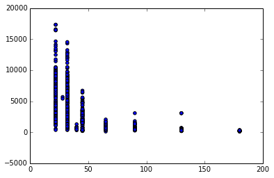

```python
plt.scatter(cpu_merged.Process, cpu_merged.Passmark,marker='o')
plt.show()
```

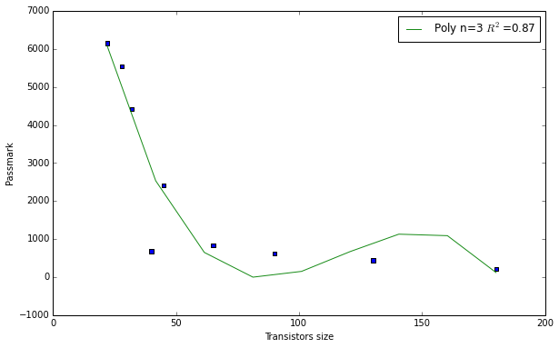

```python
test = pd.DataFrame(index=range(int(cpu_merged.Process.max()+10)), columns=['Pass','Cpus'])
test.fillna(0, inplace=True)
count=0
for x in cpu_merged.Process:
    test.Pass[x] += (cpu_merged.Passmark[count])
    test.Cpus[x]+=1
    count+=1
test = test[test.Cpus >0]
test['average'] = (test.Pass/test.Cpus)
test['nm'] = test.index
plt.figure(figsize=(6 * 1.618, 6))
# test[['average']].plot(kind='bar')
bars = plt.scatter(test.index, test.average, marker=',')
plt.xlabel("Transistors size")
plt.ylabel("Passmark")
curvLine(test.nm, test.average, test,3, 'g-')
plt.show()
```

### CPU multiplier

The graph show that the higher the multiplier the more clock speed the cpu will achieve.

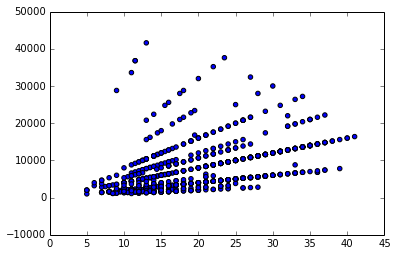

```python
plt.scatter(cpu_merged.Multi, cpu_merged.Clock*cpu_merged.Cores)
plt.show()
```

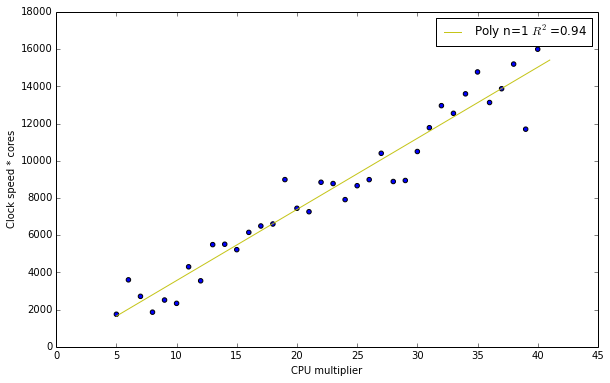

```python
test = pd.DataFrame(index=range(int(cpu_merged.Multi.max()+10)), columns=['Clock','Cpus'])
test.fillna(0, inplace=True)
count=0
for x in cpu_merged.Multi:
    test.Clock[int(x)] += cpu_merged.Clock[count]*cpu_merged.Cores[count]
    test.Cpus[int(x)]+=1
    count+=1
test = test[test.Cpus >0]
test
test['average'] = (test.Clock/test.Cpus)
test['multi'] = test.index
plt.figure(figsize=(6 * 1.618, 6))
# # test[['average']].plot(kind='bar')
bars = plt.scatter(test.index, test.average)
plt.xlabel("CPU multiplier")
plt.ylabel("Clock speed * cores")
curvLine(test.multi, test.average, test,1, 'y-')
plt.show()
```

### Released date vs power efficincy

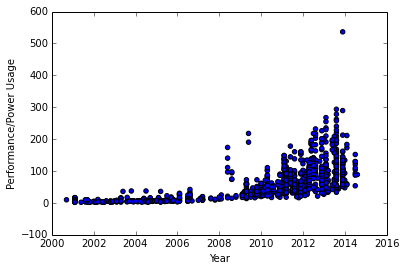

```python
plt.scatter(cpu_merged.Released, cpu_merged.PowerValue,marker='o')
plt.xlabel("Year")
plt.ylabel("Performance/Power Usage")
plt.show()
```

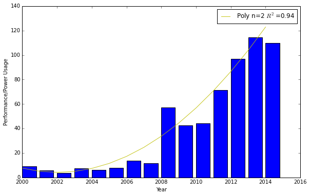

```python
data = pd.DataFrame(range(2000,2015),columns=['year'])
data['cpus'] = 0
data['total'] = 0

count = 0
for key in cpu_merged.Released:
    data.total[int(key)-2000]+=cpu_merged.PowerValue[count]
    data.cpus[int(key)-2000]+=1
    count+=1
plt.figure(figsize=(6 * 1.618, 6))
plt.bar(data.year, data.total/data.cpus)
data['average'] = data.total/data.cpus
curvLine(data.year,data.average,data,2, 'y-')
plt.xlabel("Year")
plt.ylabel("Performance/Power Usage")
plt.show()
```

# Conclusion